# College Interest Trends Regression Findings

## Regression Model 4: Final

```r
#Regression 4
reg4  <- feols(index ~ monthorweek + earnings + high_earnings + score_avail*high_earnings + f_month | schname, data = final_df_clean, vcov = 'hetero')
```

```
## NOTE: 7,355 observations removed because of NA values (RHS: 7,355).
```

```
## Variables 'earnings' and 'high_earnings' have been removed because of collinearity (see $collin.var).
```

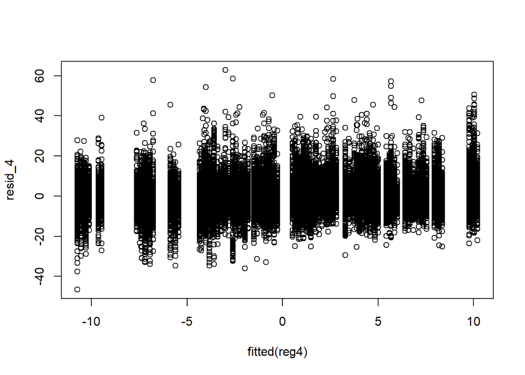

```r
resid_4 <- resid(reg4)
plot(fitted(reg4), resid_4)
```

```r
summary(reg4)
```

```
## OLS estimation, Dep. Var.: index
## Observations: 65,065
## Fixed-effects: schname: 1,779
## Standard-errors: Heteroskedasticity-robust
##                             Estimate Std. Error   t value  Pr(>|t|)
## monthorweek                -0.009210   0.000119 -77.40131 < 2.2e-16 ***
## score_avail                 1.353522   0.111860  12.10015 < 2.2e-16 ***
## f_month2                   -2.092308   0.108190 -19.33923 < 2.2e-16 ***
## f_month3                   -1.582707   0.118108 -13.40050 < 2.2e-16 ***
## f_month4                   -1.615040   0.117657 -13.72665 < 2.2e-16 ***
## f_month5                   -5.921035   0.126329 -46.87005 < 2.2e-16 ***
## f_month6                  -10.321466   0.142746 -72.30662 < 2.2e-16 ***
## f_month7                   -6.905449   0.123451 -55.93671 < 2.2e-16 ***
## f_month8                    2.020410   0.131128  15.40794 < 2.2e-16 ***
## f_month9                    4.137436   0.141606  29.21805 < 2.2e-16 ***
## f_month10                   1.765452   0.124832  14.14263 < 2.2e-16 ***
## f_month11                  -1.197386   0.128794  -9.29693 < 2.2e-16 ***
## f_month12                  -9.070864   0.125710 -72.15685 < 2.2e-16 ***
## high_earnings:score_avail  -1.367148   0.147979  -9.23877 < 2.2e-16 ***
## ... 2 variables were removed because of collinearity (earnings and high_earnings)
## ---
## Signif. codes:  0 '***' 0.001 '**' 0.01 '*' 0.05 '.' 0.1 ' ' 1
## RMSE: 6.78643     Adj. R2: 0.333683
##                 Within R2: 0.352035
```

**Comments**

```
-In this case High_earnings and Score availability: there is a -1.36 standard deviation difference on the effect of score availability on High and Low Earning schools.
-This finally answers our direct question! We aren't necessarily gauging the magnitude of the interest for each school, but rather concluding that there is a significant and definable change in interest in high and low earning schools, associated with the release of the college score card.
-Our residuals and other signifigances also look good.
```

## Regression Performance Comparison:

After the construction and review of our models, it makes the most sense to go with regression our final regression model. The reg4 model controls for the variation within schools, helping to “close back doors” on other causes that may impact interest, as well as the time of year, which we know has a firm impact on interest. The models without proper control have endogeneity issues, with omitted variable bias swaying the power of the coefficient. Additionally, without the interaction term, it is difficult to identify the close association between the treatment(score card) and our segmented groups (high and low earnings).

# Interpretation and Conclusion

The final reg4 model has a very convenient interaction term that helps us to understand there is a definable difference in interest between high and low earning schools when the score card is available. Based on our definition of high and low earning schools (grouped by median student earnings above), we see that there is a statistically significant finding of **when the score card is available there is a 1.36 standard deviation decrease in indexed interest from low earning schools to high earning schools** . This is unexpected for me, as I would have though that the score card would have increased interest in schools that have high earning students. However, it is interesting to see that there is an impact to how the public utilizes information to the determine what interests them. Perhaps this indicates that there are more important stats on the score_card that impact interest in this direction, beyond just the earnings of the schools. It could be that low earning schools tend to have other characteristics that are more appealing to potential students. Regardless, we have answered our question we set out to research, and have a significant and definable variation in interest between high and low earning schools.

## Further Research Questions:

A further way of observing this would to be of course to capture more years of data, which would help increase our understanding of the long term impact of the treatment. It is entirely possible that after only a few years of it being public, would individuals begin to fully utilize the score card. Additionally, with more data and samples of schools, we could segment the schools further. It would be fascinating to divide the set into 3 groups, low earning, average earning and high earning schools. It is possible that since the cut off is around the median, that there is too smooth of a transition for us to completely separate out the characteristics.

This project was incredibly interesting to do, and the analysis results are useful for understanding the impact of earning transparency on College Interest. Colleges could use these findings and conclusions to help drive further marketing and outreach campaigns to utilize their best windows of opportunity in attracting students. Looking further, it would be really engaging to find some data on students (perhaps in the form of a survey) that would delve into how students ended up selecting the schools they went to. Did they go to the school because of the earning potential, majors offered, or scholarships offered? This data would be useful in helping colleges gather further information on how they can attract students.